# Practical Machine Learning Prediction Assignment

MossyMoose (GitHub username of Coursera Student)

10/21/2021

## Introduction

*From the course assignment,* using devices such as Jawbone Up, Nike FuelBand, and Fitbit it is now possible to collect a large amount of data about personal activity relatively inexpensively. These type of devices are part of the quantified self movement – a group of enthusiasts who take measurements about themselves regularly to improve their health, to find patterns in their behavior, or because they are tech geeks. One thing that people regularly do is quantify how much of a particular activity they do, but they rarely quantify how well they do it. In this project, your goal will be to use data from accelerometers on the belt, forearm, arm, and dumbell of 6 participants. They were asked to perform barbell lifts correctly and incorrectly in 5 different ways. More information is available from the website here: http://groupware.les.inf.puc-rio.br/har (see the section on the Weight Lifting Exercise Dataset).

To conduct our analysis, we use the `caret` package to construct a decision/classification tree and a random forest model to predict values in a test data set of 20 observations.

## Data Collection, Preprocessing, and Exploration

We will use the `caret` package in our analysis, which we load first.

```r
library(caret)
```

Next, we download the training and test data.

```r
# Download and read in the training and testing data
# Training: https://d396qusza40orc.cloudfront.net/predmachlearn/pml-training.csv
# Test: https://d396qusza40orc.cloudfront.net/predmachlearn/pml-testing.csv

trainData<-read.csv(url("https://d396qusza40orc.cloudfront.net/predmachlearn/pml-training.csv"))
testData<-read.csv(url("https://d396qusza40orc.cloudfront.net/predmachlearn/pml-testing.csv"))
```

Since our test data is the actual data for which we need to predict values, we will split the training data into training and test sets. As is common practice, we’ll split the training data into 60% for training and 40% for testing.

```r
# Set a random number seed for reproducibility
set.seed(22740)

# Split training data into two parts, 60% for training and 40% for testing
inTrain <- createDataPartition(y=trainData$classe, p=0.6, list=FALSE)
train <- trainData[inTrain, ]
test <- trainData[-inTrain, ]

# Change test$classe to a factor variable since this will be needed later
test$classe<-as.factor(test$classe)

# Confirm size of data sets
dim(train)
```

```
## [1] 11776   160
```

```r
dim(test)
```

```
## [1] 7846  160
```

We have a 160 variables, which is a lot to work with. Next, we’ll explore the data and start to clean it with the goal of removing unneeded variables and simplifying the data set.

First, we’ll look at the first couple of rows of the data. **NOTE: This step is omitted from the report due to the length of the output.**

```r
# Look at the first few rows of data; omitted for HTML report
head(train)
```

As we can see, the first variable, `X`, appears to be an index, and the next six columns after that are informational about the samples but not of value for predictions. We’ll remove them since they’re not good predictors.

```r
# Remove the first seven columns since they're not predictors
train <- train[-c(1:7)]
```

Next, we’ll remove zero covariates. As we can see, there were 52 such variables!

```r
# Remove zero covariates
nzv<-nearZeroVar(train)
train<-train[, -nzv]

# How many near zero covariates were there?
length(nzv)
```

```
## [1] 52
```

Next, we look at how many columns have missing data and see that a lot of the variables are missing approximately 98% of values. We remove these variables by selecting only the columns with less than 95% NAs.

```r
# colMeans(is.na(train)) -- this command ommitted from final HTML for brevity
# Clean variables with too many NAs
train<-train[, colMeans(is.na(train))<.95]
```

This has left us with a much nicer data set on which to base our prediction models.

```r
#summary(train)
```

## Analysis

We are now ready to develop prediction models for consideration. We will look at two models:

1. Decision Tree
2. Random Forest

We use 3-fold cross-validation for our models.

### Decision Tree

We will construct a decision tree using `caret`’s `rpart` method. As we see from the output, we have an accuracy rate of around 50%. As we see with the table comparing predictions versus actuals, we are way off. At the end, we show the error expressed as a percentage of the total predictions, which is our out-of-sample error of about 50%.

```r
# Decision tree
modDT<-train(classe~., data=train, method="rpart",
             trControl=trainControl(method="cv", number=3, verboseIter=F))
predDT<-predict(modDT, test)
confusionMatrix(predDT, test$classe)
```

```
## Confusion Matrix and Statistics
##
##           Reference
## Prediction    A    B    C    D    E
##          A 2020  625  621  557  203
##          B   36  487   45  246  187
##          C  171  406  702  483  395
##          D    0    0    0    0    0
##          E    5    0    0    0  657
##
## Overall Statistics
##
##                Accuracy : 0.4927
##                  95% CI : (0.4816, 0.5039)
##     No Information Rate : 0.2845
##     P-Value [Acc > NIR] : < 2.2e-16
##
##                   Kappa : 0.3377
##
##  Mcnemar's Test P-Value : NA
##
## Statistics by Class:
##
##                      Class: A Class: B Class: C Class: D Class: E
## Sensitivity            0.9050  0.32082  0.51316   0.0000  0.45562
## Specificity            0.6427  0.91877  0.77539   1.0000  0.99922
## Pos Pred Value         0.5017  0.48651  0.32545      NaN  0.99245
## Neg Pred Value         0.9445  0.84938  0.88293   0.8361  0.89073
## Prevalence             0.2845  0.19347  0.17436   0.1639  0.18379
## Detection Rate         0.2575  0.06207  0.08947   0.0000  0.08374
## Detection Prevalence   0.5131  0.12758  0.27492   0.0000  0.08437
## Balanced Accuracy      0.7738  0.61980  0.64428   0.5000  0.72742
```

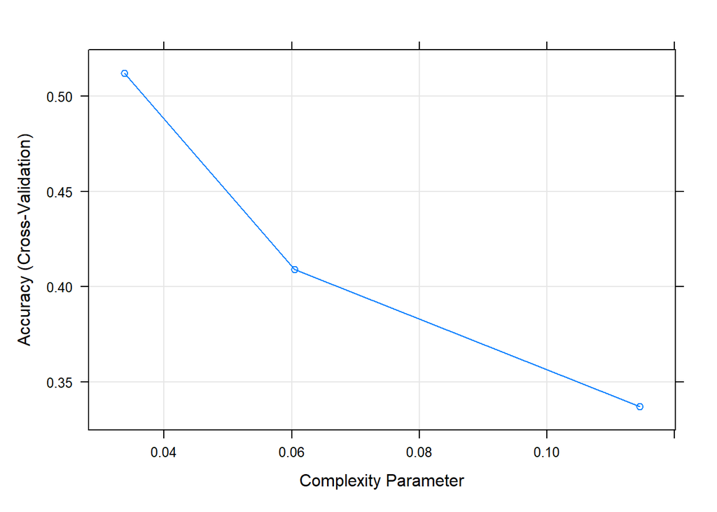

```r
plot(modDT)
```

```r
postResample(predDT, test$classe)
```

```
##  Accuracy     Kappa
## 0.4927352 0.3376907
```

```r
table(predDT, test$classe)
```

```
##
## predDT    A    B    C    D    E
##      A 2020  625  621  557  203
##      B   36  487   45  246  187
##      C  171  406  702  483  395
##      D    0    0    0    0    0
##      E    5    0    0    0  657
```

```r
sum(predDT!=test$classe)/length(predDT)
```

```
## [1] 0.5072648
```

Next, we construct a random forest model. We’re using `caret`’s `ranger` method due to the large amount of processing time the `rf` method required. The accuracy rate was over 99%, which is phenomenal. Our out-of-sample error is approximately 0.5%.

```r
# Random forest (using ranger method due to processing time)
modRF<-train(classe~., data=train, method="ranger",
             trControl=trainControl(method="cv", number=3, verboseIter=F))
predRF<-predict(modRF, test)
confusionMatrix(predRF, test$classe)
```

```
## Confusion Matrix and Statistics
##
##           Reference
## Prediction    A    B    C    D    E
##          A 2231   13    0    0    0
##          B    1 1503    7    0    0
##          C    0    2 1357   14    1
##          D    0    0    4 1272    3
##          E    0    0    0    0 1438
##
## Overall Statistics
##
##                Accuracy : 0.9943
##                  95% CI : (0.9923, 0.9958)
##     No Information Rate : 0.2845
##     P-Value [Acc > NIR] : < 2.2e-16
##
##                   Kappa : 0.9927
##
##  Mcnemar's Test P-Value : NA
##
## Statistics by Class:
##
##                      Class: A Class: B Class: C Class: D Class: E
## Sensitivity            0.9996   0.9901   0.9920   0.9891   0.9972
## Specificity            0.9977   0.9987   0.9974   0.9989   1.0000
## Pos Pred Value         0.9942   0.9947   0.9876   0.9945   1.0000
## Neg Pred Value         0.9998   0.9976   0.9983   0.9979   0.9994
## Prevalence             0.2845   0.1935   0.1744   0.1639   0.1838
## Detection Rate         0.2843   0.1916   0.1730   0.1621   0.1833
## Detection Prevalence   0.2860   0.1926   0.1751   0.1630   0.1833
## Balanced Accuracy      0.9986   0.9944   0.9947   0.9940   0.9986
```

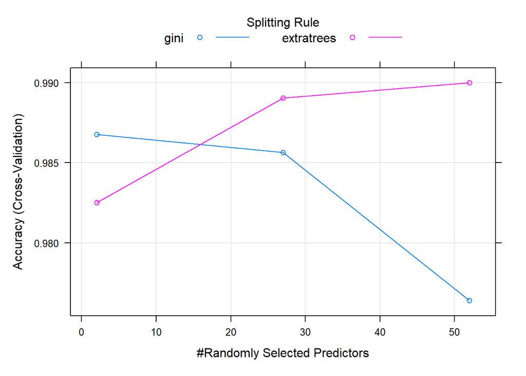

```r
plot(modRF)
```

```r
postResample(predRF, test$classe)
```

```
##  Accuracy     Kappa
## 0.9942646 0.9927441
```

```r
table(predRF, test$classe)
```

```
##
## predRF    A    B    C    D    E
##      A 2231   13    0    0    0
##      B    1 1503    7    0    0
##      C    0    2 1357   14    1
##      D    0    0    4 1272    3
##      E    0    0    0    0 1438
```

```r
sum(predRF!=test$classe)/length(predRF)
```

```
## [1] 0.005735407
```

*NOTE: We attempted to use a generalized boosted model using the `gbm` method. However, we encountered errors that we are not able to address. Therefore, we are not using the `gbm` method.*

## Selection of Final Model

Ideally we would have had more models to test, but we encountered processing issues. Of the two models, the random forest approach was by far the most accurate.

```
##    Model Accuracy
## 1   Tree   0.4927
## 2 Forest   0.9943
```

## Predictions Using Test Data

We now use our random forest model to predict using the test data in the `testData` data set. The output of this step is omitted from the write-up.

```r
testPred<-predict(modRF, testData)
# testPred
```

## For More Information

This report and supporting information is available at my [GitHub repository] (https://github.com/MossyMoose/PMLPredictionAssignment).